# Mokelumne River

Sadie Gill, Mark Tompkins

July 2020

## Future Data Improvements

- EBMUD is developing new steelhead rearing habitat flow:area relationships (expected 2020)
- EBMUD is developing new Fall Run floodplain rearing habitat flow:area relationships with Mark Gard (expected 2020)

## Instream Spawning and Rearing Habitat

**Data Sources:** [CDFW 1991](https://s3-us-west-2.amazonaws.com/cvpiahabitat-r-package/cvpia-sit-model-inputs/Lower+Mokelumne+RIver+Fisheries+Management+Plan%2C+CDFG+1991.pdf) (pg. 105 - 107)

Instream spawning and rearing habitat for Fall Run Chinook Salmon and Steelhead in the Mokelumne River is based on data from USFWS’s 1998 instream flow evaluation and EBMUD’s 2016 instream habitat evaluation. The East Bay Municipal Utility Distract (EBMUD) instream spawning and rearing habitat data were provided in a spreadsheet. Together, these evaluations determined relationships between flow and both suitable spawning and rearing habitat for reaches spanning approximately 35 miles of the Mokelumne River.

### Combine Instream Spawning and Rearing Habitat Data

The instream spawning and rearing habitat data described above are combined for use in the Decision Support Model (DSM) in the following format. Units are in square feet per 1000 feet.

Header Descriptions: flow_cfs = flow in cubic feet per second, FR_spawn_wua = Fall Run Chinook Spawning wua, FR_fry_wua = Fall Run Chinook Fry wua, FR_juv_wua = Fall Run Chinook Juvenile wua, ST_spawn_wua = Steelhead Spawning wua, watershed = section of stream modeled for CVPIA SDM

| flow_cfs | FR_spawn_wua | FR_fry_wua | FR_juv_wua | ST_spawn_wua | watershed |
| --- | --- | --- | --- | --- | --- |
| 100 | NA | 26783.27 | 29606.59 | NA | Mokelumne River |
| 105 | 5662.441 | 26584.44 | 29465.08 | 3969.682 | Mokelumne River |
| 140 | 7016.761 | 25234.03 | 28541.24 | 5167.945 | Mokelumne River |
| 180 | 8240.197 | 23675.02 | 27441.99 | 6462.489 | Mokelumne River |
| 200 | NA | 22880.65 | 26872.73 | NA | Mokelumne River |

*… with 12 more rows*

### Spawning WUA

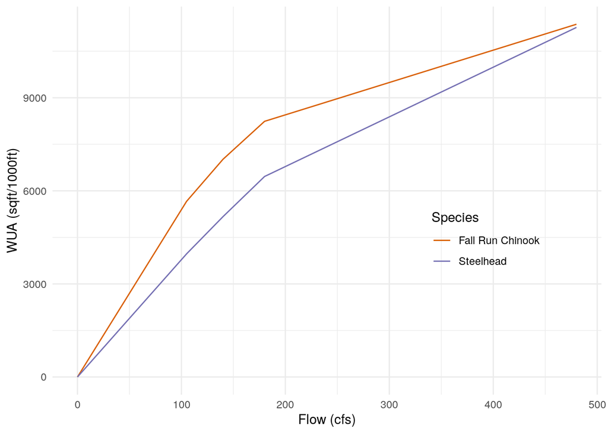

### Rearing WUA

The flow:area relationships from USFWS and EBMUD were first expanded using linear interpolation to ensure the relationships for each evaluation reach included the same flows. A single rearing habitat area representing the entire river was then estimated for each flow. Each area was weighted in proportion to the length of the evaluation reach from which the area was originally estimated. The resulting areas were then converted to an area per unit length by dividing the area by the length of the rearing reach mapped by the Scince Integration Team (SIT).

The following plot shows the rearing WUA in square feet per thousand feet for Fall Run Chinook Salmon fry and juvenile.

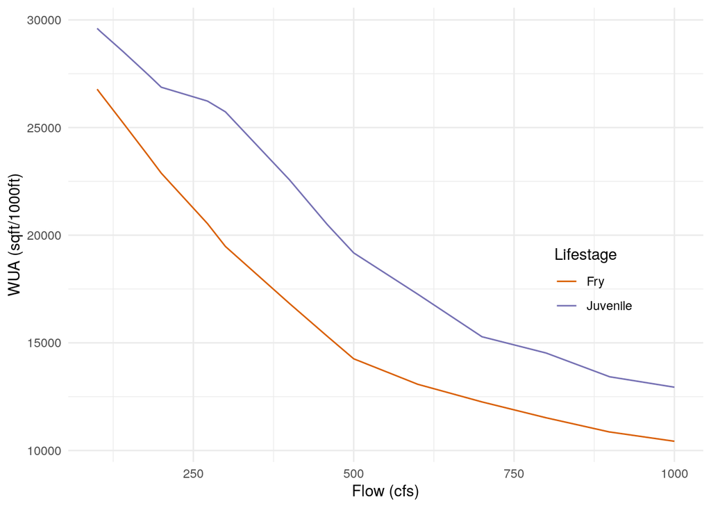

## Floodplain Rearing Habitat

**Data Source:** [CVPIA Annual Progress Report Fiscal Year 2019](https://cvpiahabitat-r-package.s3-us-west-2.amazonaws.com/CVPIA+Annual+Progress+Report+Fiscal+Year+2019.pdf)

Header Descriptions: flow_cfs = flow in cubic feet per second, FR_floodplain_acres = Fall Run Chinook floodplain acres, SR_floodplain_acres = Spring Run Chinook floodplain acres, ST_floodplain_acres = Steelhead floodplain acres, watershed = section of stream modeled for CVPIA SDM

| flow_cfs | FR_floodplain_acres | SR_floodplain_acres | ST_floodplain_acres | watershed |
| --- | --- | --- | --- | --- |
| 400 | 0.0000 | 0.0000 | 0.0000 | Mokelumne River |
| 800 | 135.4992 | 135.4992 | 135.4992 | Mokelumne River |
| 900 | 160.7151 | 160.7151 | 160.7151 | Mokelumne River |
| 1100 | 203.6763 | 203.6763 | 203.6763 | Mokelumne River |
| 1300 | 239.4405 | 239.4405 | 239.4405 | Mokelumne River |

*… with 2 more rows*

## Floodplain Plot

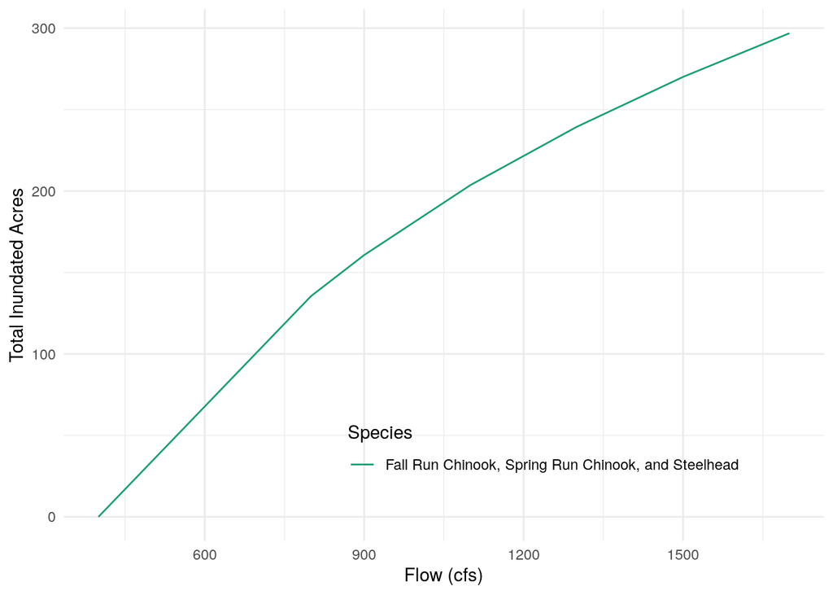